# 4: Normal distributions, correlations

Frank Edwards

# Random Variables

## Random Variables

- Random variables assign values to events
- Each value is mutually exclusive
- The set of all values is exhaustive (the sample space $\Omega$)
- Discrete random variables take a finite number of values (e.g. TRUE, FALSE)
- Continuous random variables are real numbers, and take on an infinite number of values

## The expectation of a random variable

- The expectation of a random variable $E(X)$ is the mean.

## Variance and standard deviation

- The standard deviation $sd$ measures the average difference of observations from the mean

$$sd = \sqrt{\frac{1}{n}\sum_{i=1}^n{(x_i-\bar{x}})^2}$$

- Sometimes we use the variance, which is $sd^2$

## The Normal Distribution

The Normal (Gaussian) distribution is continuous, and takes on values from $[-\infty, \infty]$. It has two parameters, the mean $\mu$ and standard deviation $\sigma$ (or variance $\sigma^2$).

- $\mu$ determines the location of the distribution
- $\sigma$ determines the spread of the distribution

# The location parameter

## The Normal PDF

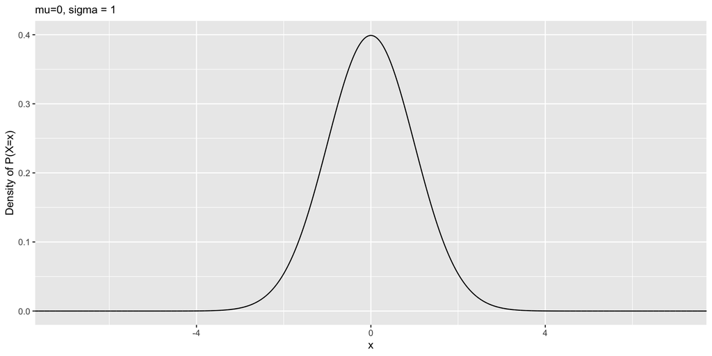

## The Normal PDF

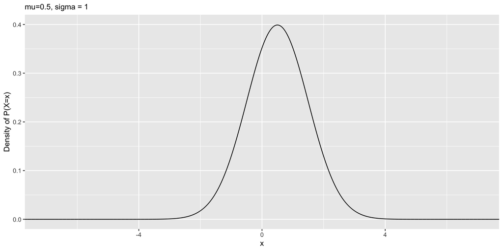

## The Normal PDF

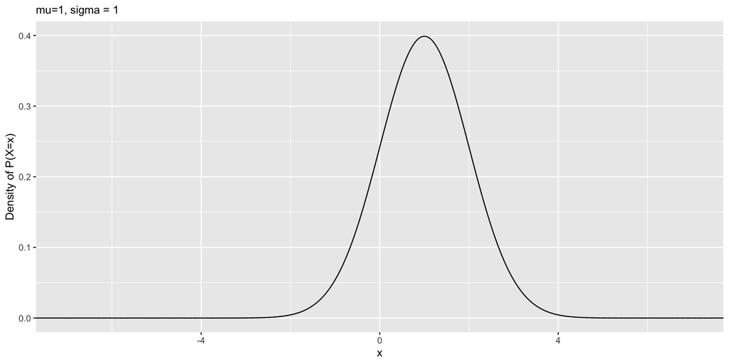

## The Normal PDF

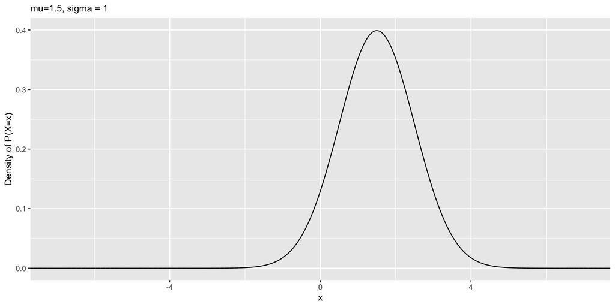

## The Normal PDF

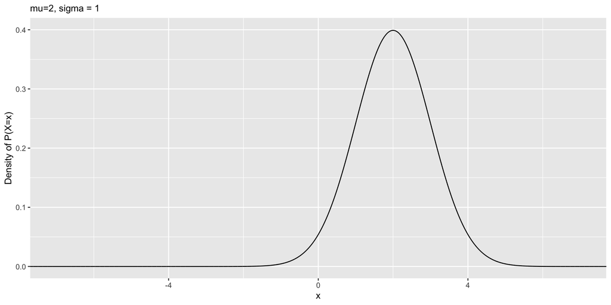

## The Normal PDF

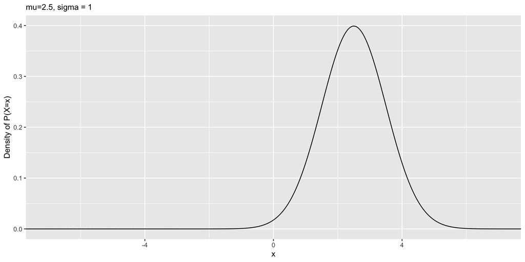

## The Normal PDF

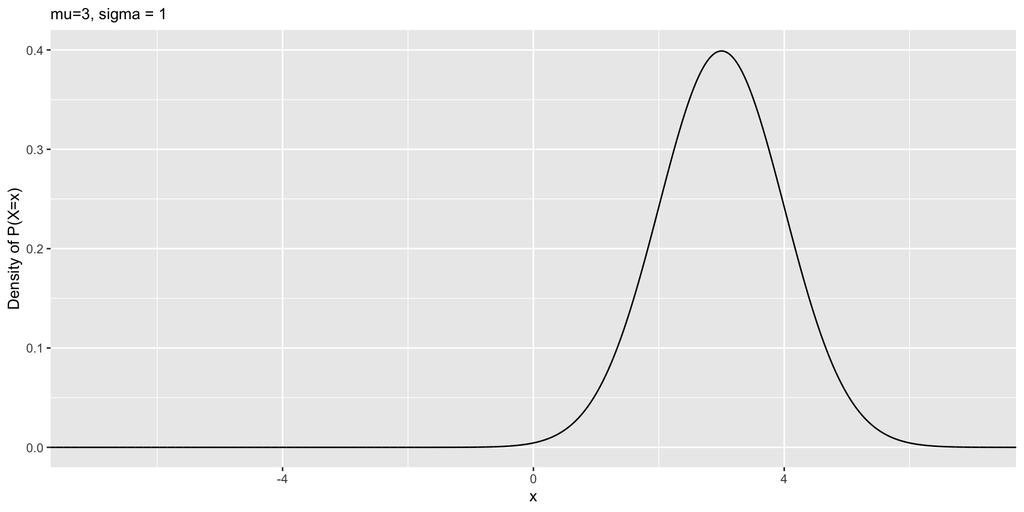

## The Normal PDF

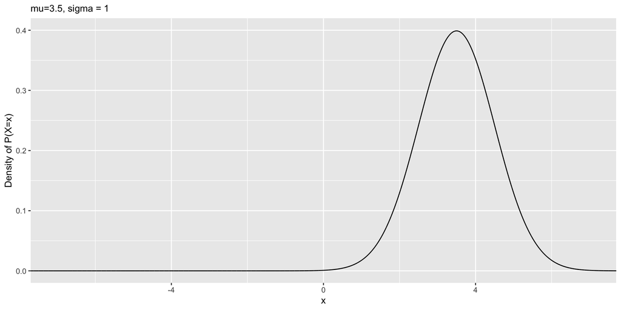

## The Normal PDF

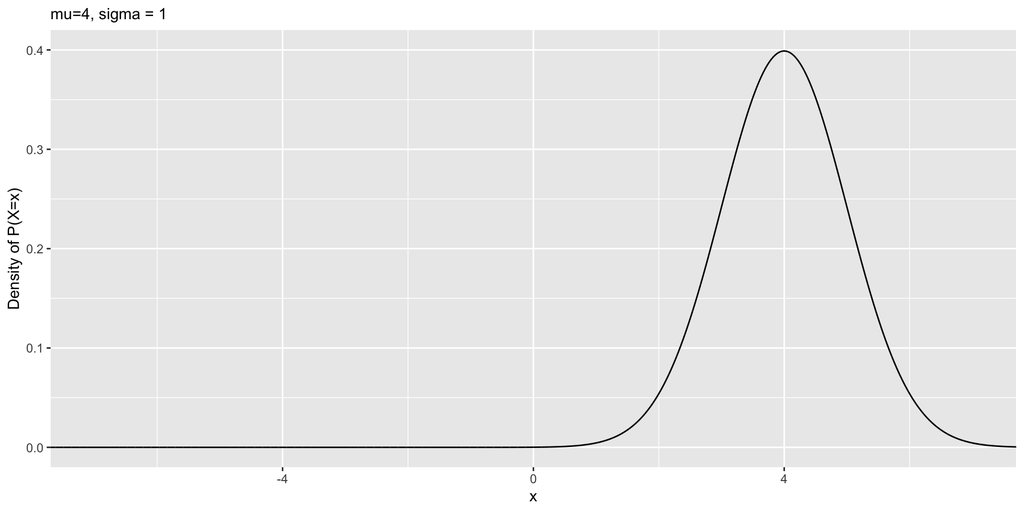

# The variance parameter

## The Normal PDF

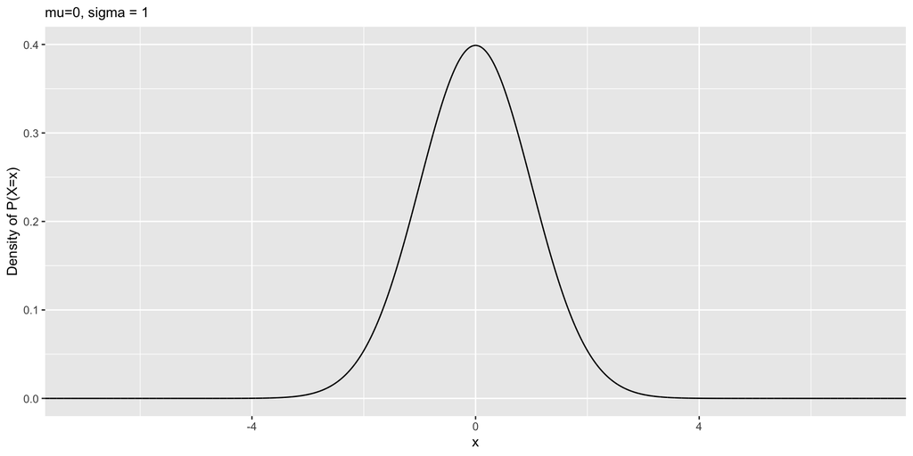

## The Normal PDF

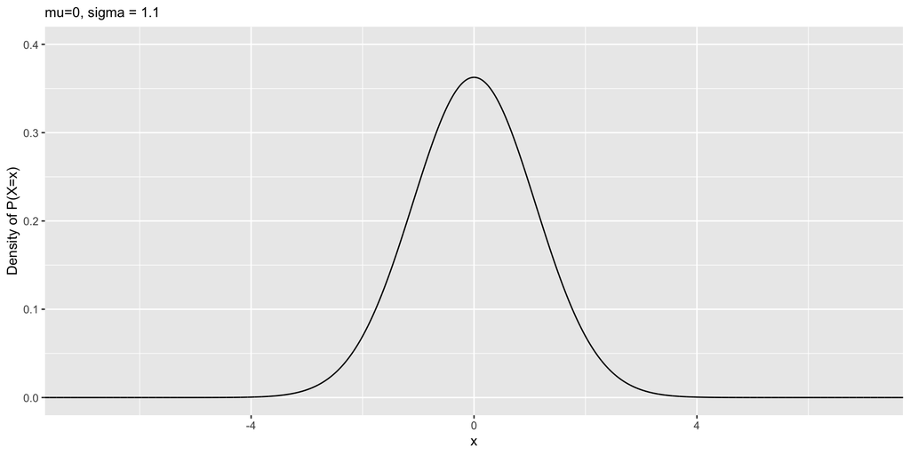

## The Normal PDF

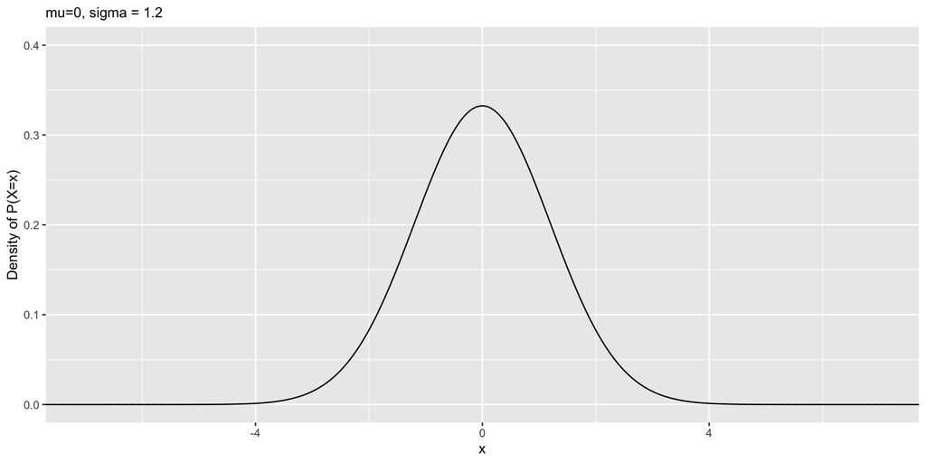

## The Normal PDF

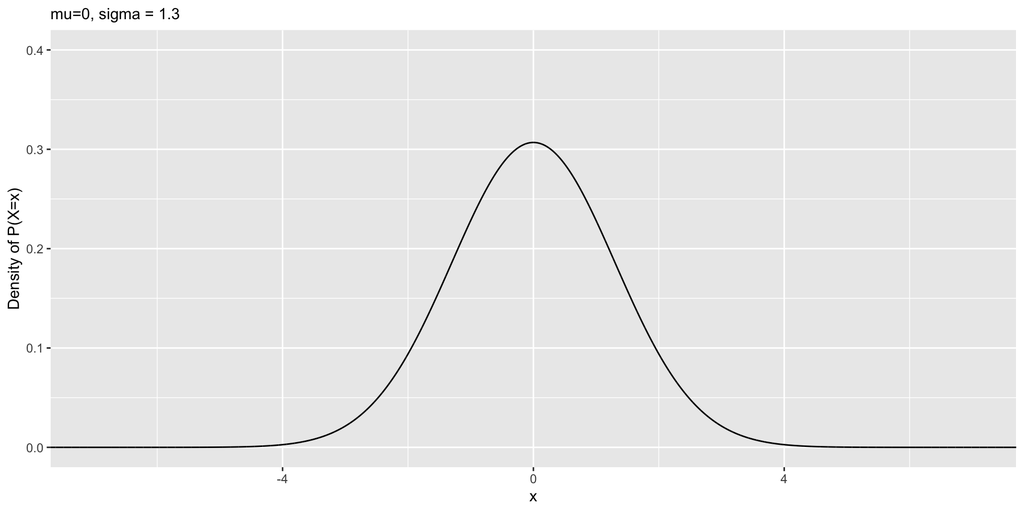

## The Normal PDF

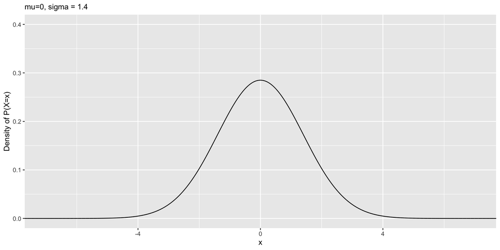

## The Normal PDF

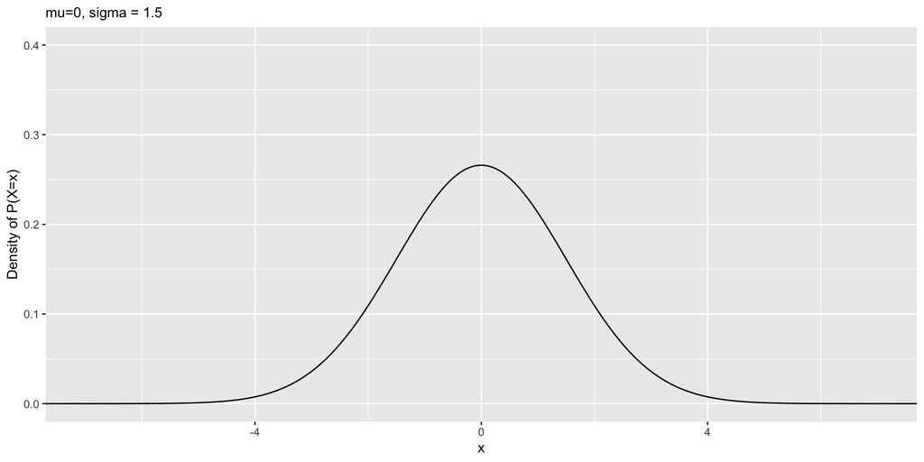

## The Normal PDF

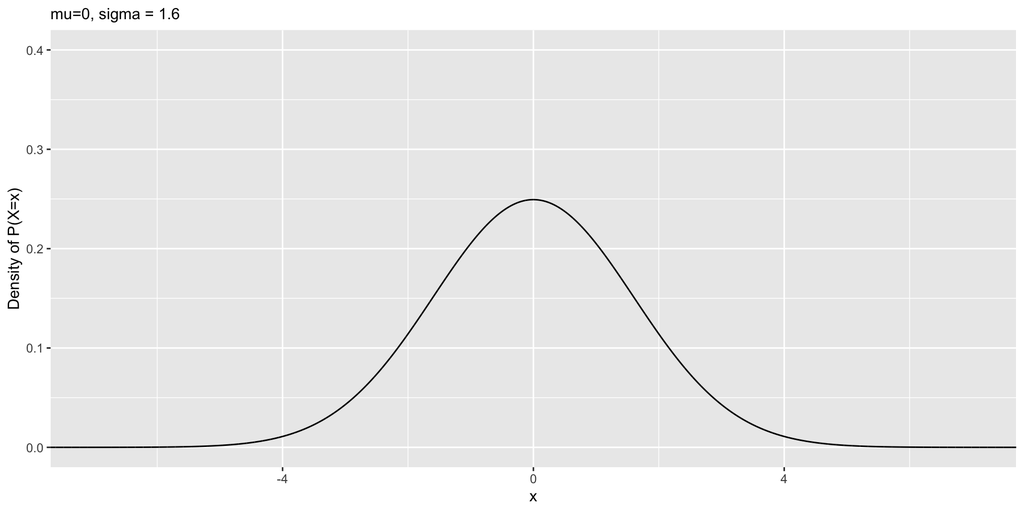

## The Normal PDF

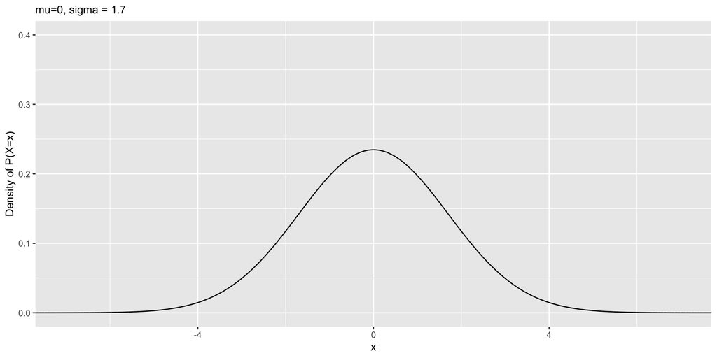

## The Normal PDF

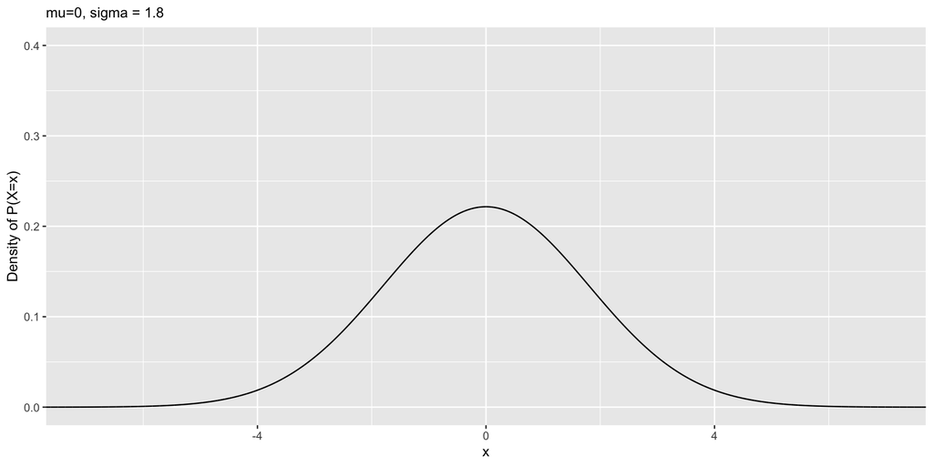

## The Normal PDF

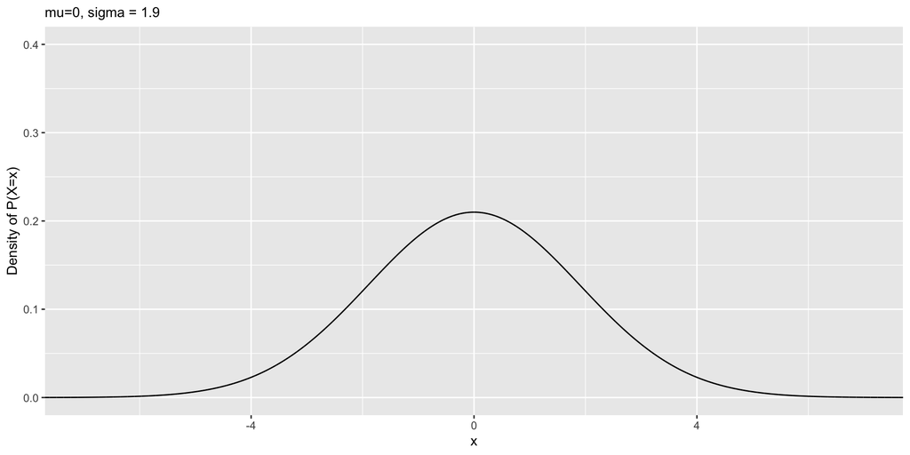

## The Normal PDF

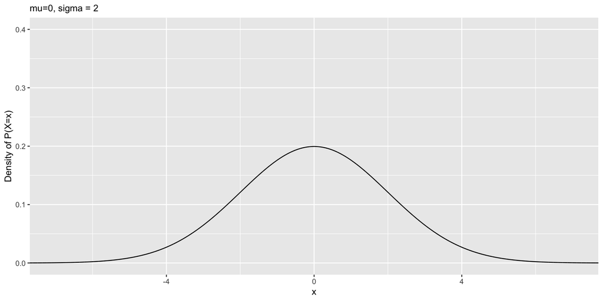

## The Normal Cumulative Distribution Function

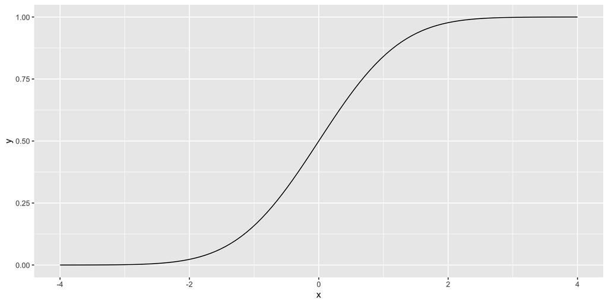

## Interpreting the PDF and CDF

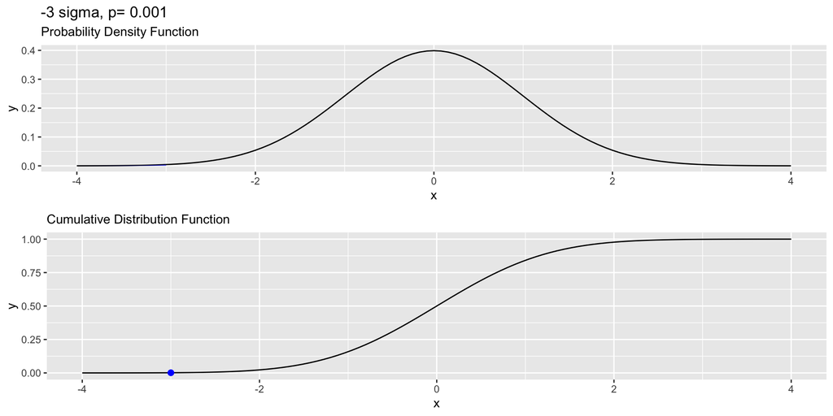

## Interpreting the PDF and CDF

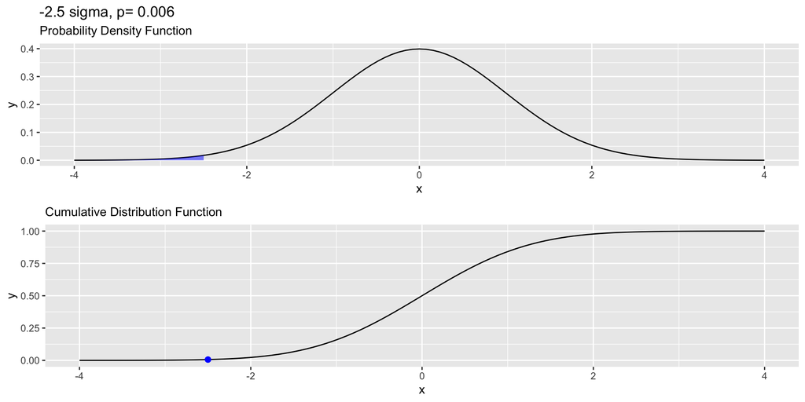

## Interpreting the PDF and CDF

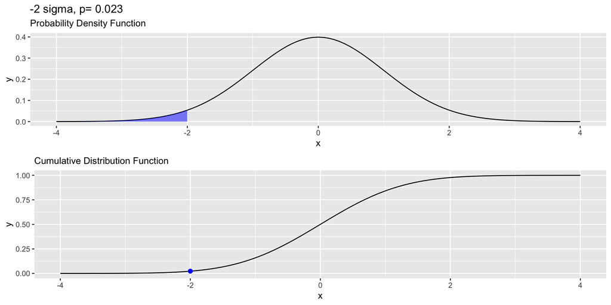

## Interpreting the PDF and CDF

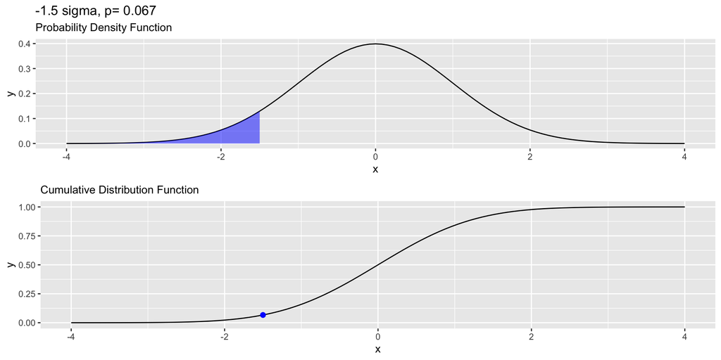

## Interpreting the PDF and CDF

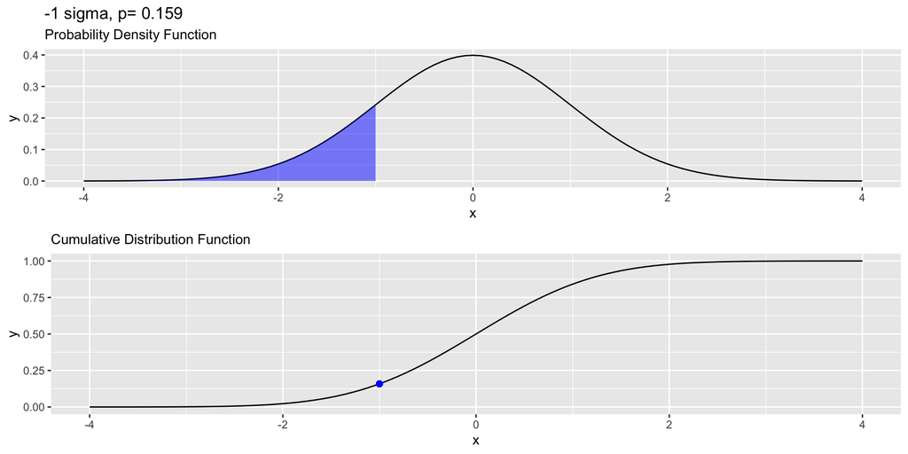

## Interpreting the PDF and CDF

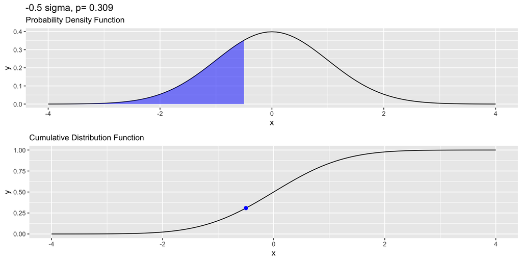

## Interpreting the PDF and CDF

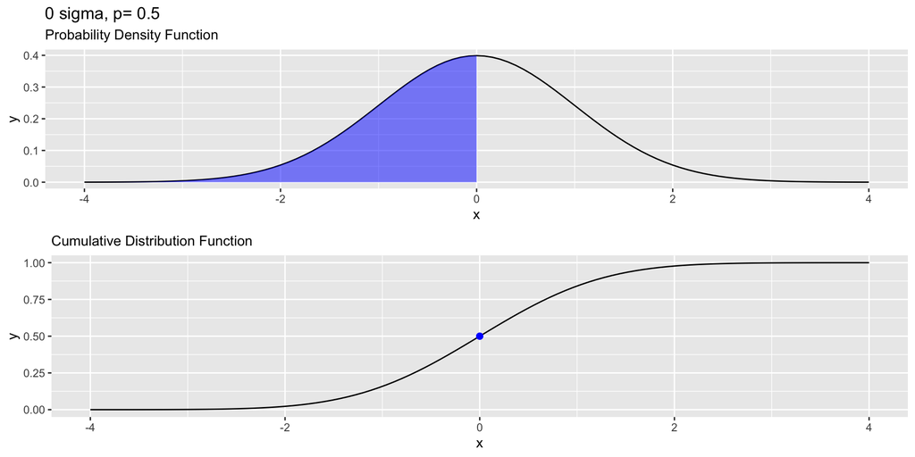

## Interpreting the PDF and CDF

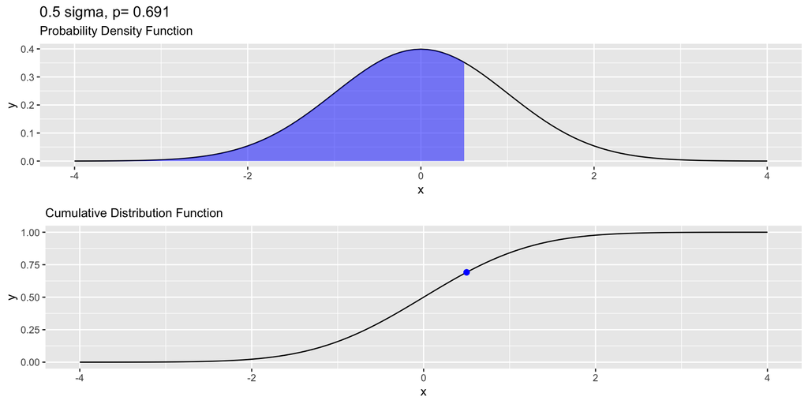

## Interpreting the PDF and CDF

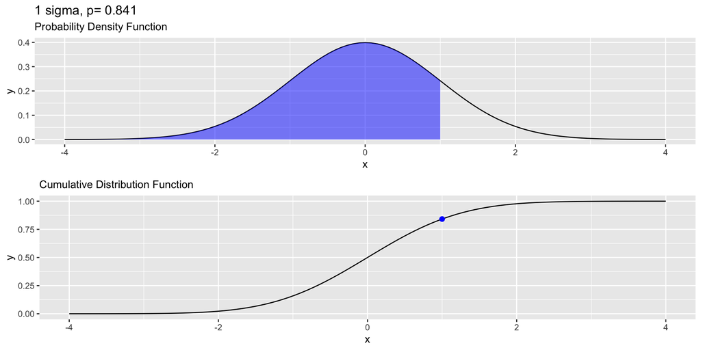

## Interpreting the PDF and CDF

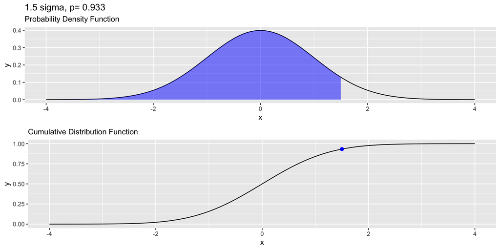